# Lab 4

Anders Lie

3/19/2021

```r
library(tidyverse)
library(rmarkdown)
def <- readxl::read_excel('cyclonesFootball2020.xlsx', sheet='Defensive')
ofn <- readxl::read_excel('cyclonesFootball2020.xlsx', sheet='Offensive')
bio <- readxl::read_excel('cyclonesFootball2020.xlsx', sheet='Biography')
```

# Part One: Data Cleaning

## 1

```r
def <- def %>%
  mutate(Name=as.factor(Name), Opponent_Opponent=as.factor(Opponent_Opponent))
ofn <- ofn %>%
  mutate(Name=as.factor(Name), Opponent_Opponent=as.factor(Opponent_Opponent))
bio <- bio %>%
  mutate(Name=as.factor(Name))
```

Here we simply use as.factor to turn the character columns into factor columns.

## 2

```r
def <- def %>%
  mutate(across(Tackles_Solo:Pass_PB, as.numeric))
ofn <- ofn %>%
  mutate(across(Receiving_REC:Passing_INT, as.numeric))
bio <- bio %>%
  mutate(Weight=as.numeric(Weight))
```

Using across and as.numeric, we easily convert all player statistics as well as weight to numeric.

## 3

```r
bio <- bio %>%
  separate(Height, into=c('HeightFeet', 'HeightInches'), sep='-') %>%
  mutate(across(c(HeightFeet, HeightInches), as.numeric)) %>%
  mutate(Height=12*HeightFeet + HeightInches) %>%
  select(-HeightFeet, -HeightInches)
```

I convert height to be inches only by separating the string and then recombining using inches = 12 times feet plus extra inches.

Here we can see the structure of the cleaned data:

```r
defClean <- def
offClean <- ofn
bioClean <- bio

str(defClean)
```

```
## tibble [372 x 11] (S3: tbl_df/tbl/data.frame)
##  $ Name             : Factor w/ 37 levels "Akers, Landen",..: 26 26 26 26 26 26 26 26 26 26 ...
##  $ Opponent_Opponent: Factor w/ 11 levels "Baylor","Kansas",..: 4 8 5 10 6 2 1 3 9 11 ...
##  $ Tackles_Solo     : num [1:372] 2 6 6 3 7 4 7 4 4 2 ...
##  $ Tackles_ASST     : num [1:372] 4 4 5 0 3 1 4 3 9 3 ...
##  $ Tackles_TFL      : num [1:372] 1 0 1.5 1 1 0 1.5 2.5 1.5 0 ...
##  $ Tackles_Sack     : num [1:372] 0 0 0.5 0 0 0 0 1 0 0 ...
##  $ Turnover_FF      : num [1:372] 0 0 0 0 0 0 0 0 0 0 ...
##  $ Turnover_FR      : num [1:372] 0 0 0 0 0 0 0 0 0 0 ...
##  $ Turnover_INT     : num [1:372] 0 1 0 0 1 0 1 1 0 0 ...
##  $ Pass_QBH         : num [1:372] 0 0 1 0 0 0 2 1 0 0 ...
##  $ Pass_PB          : num [1:372] 0 0 0 0 0 1 0 0 1 0 ...
```

```r
str(offClean)
```

```
## tibble [156 x 12] (S3: tbl_df/tbl/data.frame)
##  $ Name             : Factor w/ 16 levels "Akers, Landen",..: 1 1 1 1 1 1 1 1 1 1 ...
##  $ Opponent_Opponent: Factor w/ 11 levels "Baylor","Kansas",..: 4 8 5 10 6 2 1 3 9 11 ...
##  $ Receiving_REC    : num [1:156] 0 2 1 4 0 6 1 0 1 1 ...
##  $ Receiving_YDS    : num [1:156] 0 60 35 34 0 76 11 0 10 2 ...
##  $ Receiving_TD     : num [1:156] 0 0 0 0 0 0 0 0 0 1 ...
##  $ Rushing_ATT      : num [1:156] NA NA NA NA NA NA NA NA NA NA ...
##  $ Rushing_YDS      : num [1:156] NA NA NA NA NA NA NA NA NA NA ...
##  $ Rushing_TD       : num [1:156] NA NA NA NA NA NA NA NA NA NA ...
##  $ Passing_CMP-ATT  : num [1:156] NA NA NA NA NA NA NA NA NA NA ...
##  $ Passing_YDS      : num [1:156] NA NA NA NA NA NA NA NA NA NA ...
##  $ Passing_TD       : num [1:156] NA NA NA NA NA NA NA NA NA NA ...
##  $ Passing_INT      : num [1:156] NA NA NA NA NA NA NA NA NA NA ...
```

```r
str(bioClean)
```

```
## tibble [116 x 7] (S3: tbl_df/tbl/data.frame)
##  $ Name      : Factor w/ 116 levels "Akers, Landen",..: 1 2 3 4 5 6 7 8 9 10 ...
##  $ Position  : chr [1:116] "Wide Receiver" "Tight End" "Wide Receiver" "Defensive Back" ...
##  $ Weight    : num [1:116] 191 240 208 180 195 199 253 261 288 182 ...
##  $ Class     : chr [1:116] "Redshirt Senior" "Redshirt Senior" "Redshirt Freshman" "Freshman" ...
##  $ Hometown  : chr [1:116] "Cedar Rapids, Iowa" "Nixa, Mo." "Seffner, Fla." "Ft. Lauderdale, Fla." ...
##  $ Highschool: chr [1:116] "Washington" "Nixa" "Armwood" "Cardinal Gibbons" ...
##  $ Height    : num [1:116] 72 79 77 72 72 72 75 74 74 74 ...
```

# Part Two: Tidying Data

## 1

```r
defClean <- defClean %>%
  pivot_longer(Tackles_Solo:Pass_PB, names_to="stat")

offClean <- offClean %>%
  pivot_longer(Receiving_REC:Passing_INT, names_to="stat")

str(defClean)
```

```
## tibble [3,348 x 4] (S3: tbl_df/tbl/data.frame)
##  $ Name             : Factor w/ 37 levels "Akers, Landen",..: 26 26 26 26 26 26 26 26 26 26 ...
##  $ Opponent_Opponent: Factor w/ 11 levels "Baylor","Kansas",..: 4 4 4 4 4 4 4 4 4 8 ...
##  $ stat             : chr [1:3348] "Tackles_Solo" "Tackles_ASST" "Tackles_TFL" "Tackles_Sack" ...
##  $ value            : num [1:3348] 2 4 1 0 0 0 0 0 0 6 ...
```

```r
str(offClean)
```

```
## tibble [1,560 x 4] (S3: tbl_df/tbl/data.frame)
##  $ Name             : Factor w/ 16 levels "Akers, Landen",..: 1 1 1 1 1 1 1 1 1 1 ...
##  $ Opponent_Opponent: Factor w/ 11 levels "Baylor","Kansas",..: 4 4 4 4 4 4 4 4 4 4 ...
##  $ stat             : chr [1:1560] "Receiving_REC" "Receiving_YDS" "Receiving_TD" "Rushing_ATT" ...
##  $ value            : num [1:1560] 0 0 0 NA NA NA NA NA NA NA ...
```

Here we see that defClean and offClean contain the data in a long format.

## 2

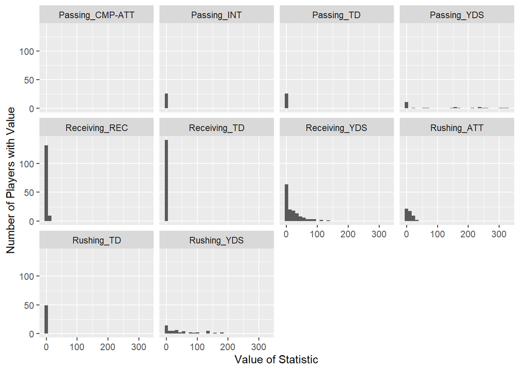

```r
offClean %>% ggplot(aes(x=value)) + geom_histogram() + facet_wrap(~stat) +
  xlab('Value of Statistic') + ylab('Number of Players with Value')
```

We see that the number of Passing_INT, Passing_TD, Receiving_REC, Receiving_TD, and Rushing_TD is relatively low across players, whereas statistics like Passing_YDS, Receiving_YDS, Rushing_ATT, and Rushing_YDS are more broadly distributed.

## 3

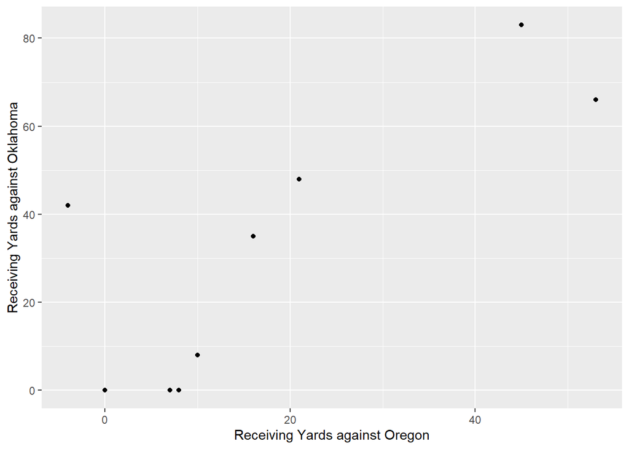

```r
offClean %>%
  filter(Opponent_Opponent %in% c('Oregon', 'Oklahoma')) %>%
  filter(stat=='Receiving_YDS') %>%
  distinct(Name, Opponent_Opponent, .keep_all=TRUE) %>%
  pivot_wider(names_from=Opponent_Opponent, values_from=value) %>%
  ggplot(aes(x=Oregon, y=Oklahoma)) + geom_point() +
  xlab('Receiving Yards against Oregon') +
  ylab('Receiving Yards against Oklahoma')
```

It seems as though in general, ISU did better against Oklahoma, since there were a few players who did around 40 yards against Oklahoma as opposed to around 20 against Oregon, as well as a couple outliers who had around 60 and 80 against Oklahoma nd only around 50 against Oregon.

## 4

```r
bio1 <- bio %>%
  separate(Hometown, into=c('City', 'State'), sep=', ')
head(bio1)
```

```
## # A tibble: 6 x 8
##   Name         Position    Weight Class       City     State Highschool   Height
##   <fct>        <chr>        <dbl> <chr>       <chr>    <chr> <chr>         <dbl>
## 1 Akers, Land~ Wide Recei~    191 Redshirt S~ Cedar R~ Iowa  Washington       72
## 2 Allen, Chase Tight End      240 Redshirt S~ Nixa     Mo.   Nixa             79
## 3 Anderson, E~ Wide Recei~    208 Redshirt F~ Seffner  Fla.  Armwood          77
## 4 Antoine Jr.~ Defensive ~    180 Freshman    Ft. Lau~ Fla.  Cardinal Gi~     72
## 5 Assalley, C~ Placekicker    195 Redshirt S~ Napervi~ Ill.  Central          72
## 6 Azunna, Arn~ Defensive ~    199 Redshirt S~ Grand P~ Texas Lake Ridge       72
```

Here we can see that the hometown has been separated into City and State columns.

## 5

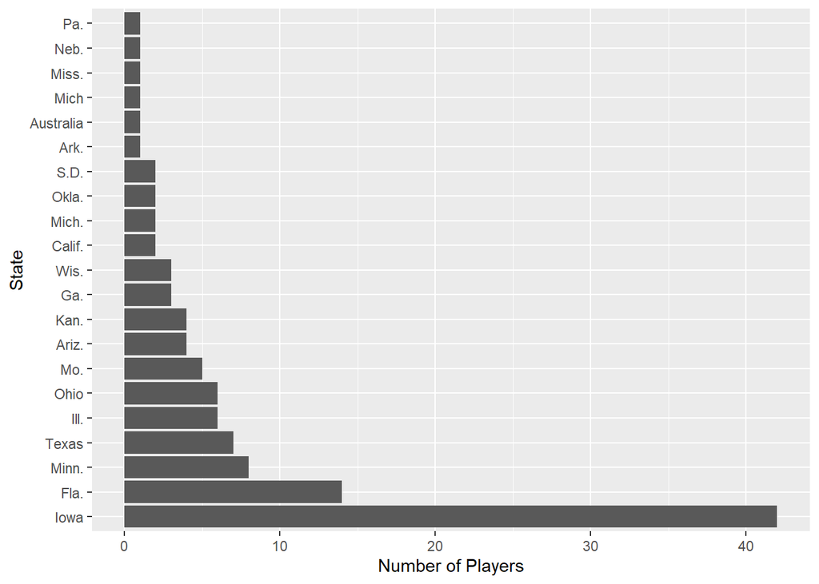

```r
bio1 %>%
  ggplot(aes(x=fct_infreq(State))) + geom_bar() + coord_flip() +
  ylab('Number of Players') + xlab('State')
```

# Part Three: Joining Data Frames

## 1

```r
# States of Defensive players
def_states <- def %>% left_join(bio1) %>% distinct(Name, .keep_all=TRUE)
```

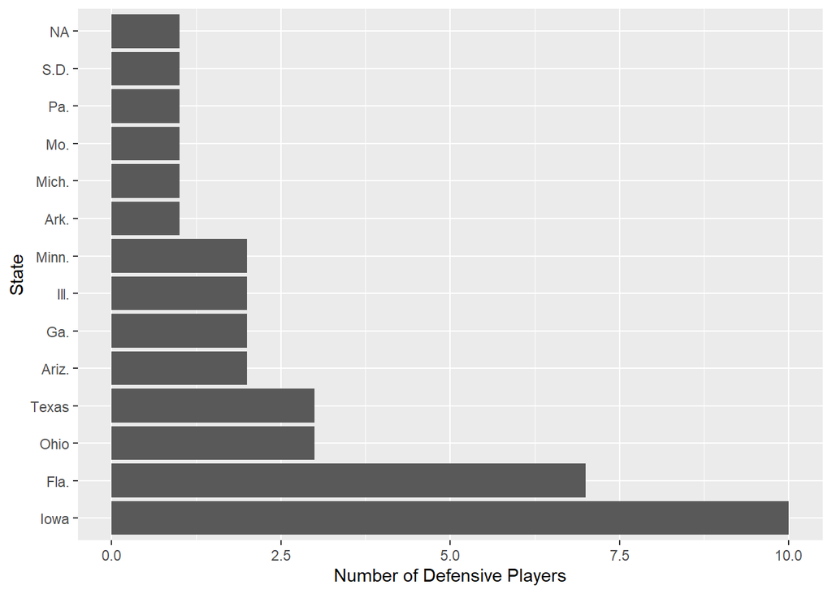

```r
def_states %>%
  ggplot(aes(x=fct_infreq(State))) + geom_bar() + coord_flip() +
  ylab('Number of Defensive Players') + xlab('State')
```

```r
# States of Offensive players
ofn_states <- ofn %>% left_join(bio1) %>% distinct(Name, .keep_all=TRUE)
```

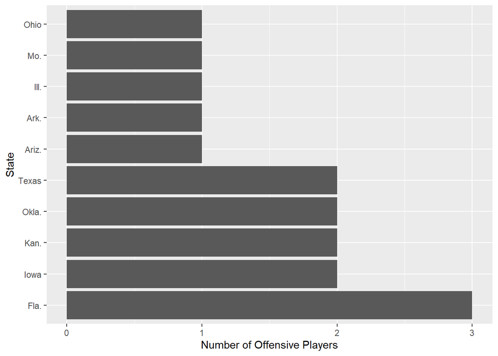

```r
ofn_states %>%
  ggplot(aes(x=fct_infreq(State))) + geom_bar() + coord_flip() +
  ylab('Number of Offensive Players') + xlab('State')
```

# 2

```r
purdy_def <- def %>% filter(Name == 'Purdy, Brock')

not_zero <- function(x){return(x != 0)}

purdy_def %>% mutate(across(Tackles_Solo:Pass_PB, not_zero)) %>% paged_table
```

| Name | Opponent_Opponent | Tackles_Solo | Tackles_ASST | Tackles_TFL | Tackles_Sack | Turnover_FF | Turnover_FR | Turnover_INT | Pass_QBH | Pass_PB |
| --- | --- | --- | --- | --- | --- | --- | --- | --- | --- | --- |
| Purdy, Brock | Louisiana | FALSE | FALSE | FALSE | FALSE | FALSE | FALSE | FALSE | FALSE | FALSE |
| Purdy, Brock | TCU | FALSE | FALSE | FALSE | FALSE | FALSE | FALSE | FALSE | FALSE | FALSE |
| Purdy, Brock | Oklahoma | FALSE | FALSE | FALSE | FALSE | FALSE | FALSE | FALSE | FALSE | FALSE |
| Purdy, Brock | Texas Tech | TRUE | FALSE | FALSE | FALSE | FALSE | FALSE | FALSE | FALSE | FALSE |
| Purdy, Brock | Oklahoma St. | FALSE | FALSE | FALSE | FALSE | FALSE | FALSE | FALSE | FALSE | FALSE |
| Purdy, Brock | Kansas | FALSE | FALSE | FALSE | FALSE | FALSE | FALSE | FALSE | FALSE | FALSE |
| Purdy, Brock | Baylor | FALSE | FALSE | FALSE | FALSE | FALSE | FALSE | FALSE | FALSE | FALSE |
| Purdy, Brock | Kansas State | FALSE | FALSE | FALSE | FALSE | FALSE | FALSE | FALSE | FALSE | FALSE |
| Purdy, Brock | Texas | FALSE | FALSE | FALSE | FALSE | FALSE | FALSE | FALSE | FALSE | FALSE |
| Purdy, Brock | West Virginia | FALSE | FALSE | FALSE | FALSE | FALSE | FALSE | FALSE | FALSE | FALSE |

[output cut: 2 more lines]

We can see there is only one nonzero statistic for Purdy on defense, so there is not enough data to try and determine his defensive contribution. Therefore we will focus on his offensive contributions.

We will compare the performance of Purdy to the rest of the team by showing the all the teams statistics, with Purdy’s highlighted in red:

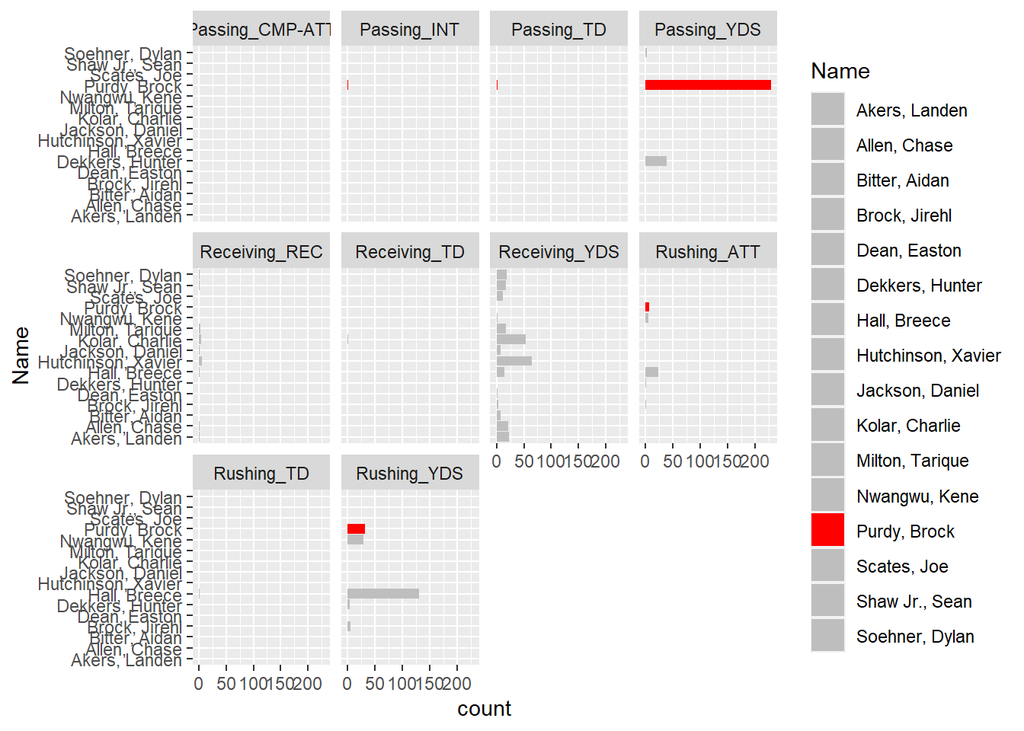

```r
cols <- c("Purdy, Brock"="red",
          "Akers, Landen"="grey",
          "Brock, Jirehl"="grey",
          "Hutchinson, Xavier"="grey",
          "Nwangwu, Kene"="grey",
          "Scates, Joe"="grey",
          "Soehner, Dylan"="grey",
          "Hall, Breece"="grey",
          "Dekkers, Hunter"="grey",
          "Kolar, Charlie"="grey",
          "Allen, Chase"="grey",
          "Shaw Jr., Sean"="grey",
          "Milton, Tarique"="grey",
          "Bitter, Aidan"="grey",
          "Jackson, Daniel"="grey",
          "Dean, Easton"="grey")

offClean %>%
  group_by(Name, stat) %>%
  summarize(avg_val=mean(value, na.rm=TRUE)) %>%
  ggplot(aes(x=Name, weight=avg_val, fill=Name)) + geom_bar() +
  facet_wrap(~stat) + coord_flip() +
  scale_fill_manual(values=cols)
```

We can see that, compared to the rest of the team, Purdy has far more passing yards. Other than that, he has no particularly large statistics. I believe this is because he is the quarterback.

## 3

Note that we will only compare ISU players who have records in both 2019 and 2020, otherwise of course we cannot see how much they improved.

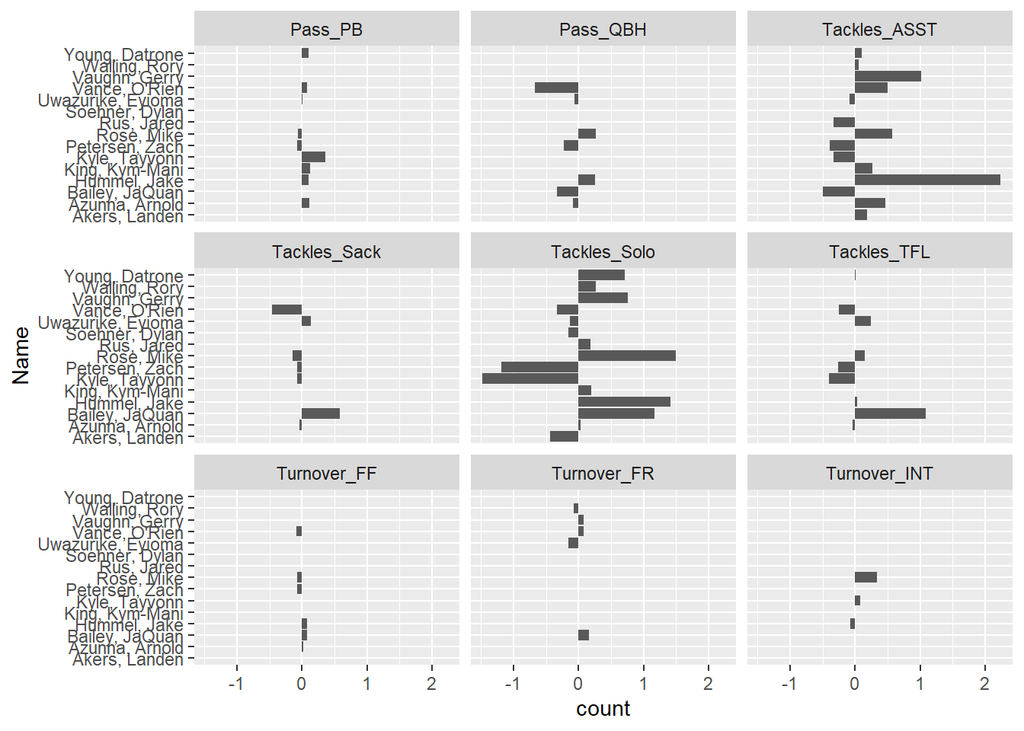

```r
def2019 <- readxl::read_excel('cyclonesFootball2019.xlsx', sheet='Defensive')
ofn2019 <- readxl::read_excel('cyclonesFootball2019.xlsx', sheet='Offensive')
bio2019 <- readxl::read_excel('cyclonesFootball2019.xlsx', sheet='Biography')

def2019 <- def2019 %>%
  mutate(Name=as.factor(Name), Opponent_Opponent=as.factor(Opponent_Opponent))
ofn2019 <- ofn2019 %>%
  mutate(Name=as.factor(Name), Opponent_Opponent=as.factor(Opponent_Opponent))
bio2019 <- bio2019 %>%
  mutate(Name=as.factor(Name))

def2019 <- def2019 %>%
  mutate(across(Tackles_Solo:Pass_PB, as.numeric))
ofn2019 <- ofn2019 %>%
  mutate(across(Rushing_ATT:Passing_INT, as.numeric))
def2019_long <- def2019 %>%
  pivot_longer(Tackles_Solo:Pass_PB, names_to="stat")

ofn2019_long <- ofn2019 %>%
  pivot_longer(Rushing_ATT:Passing_INT, names_to="stat")

def2019avg <- def2019_long %>%
  filter(Name %in% defClean$Name) %>%
  group_by(Name, stat) %>%
  summarize(avg_val=mean(value))
def2020avg <- defClean %>%
  filter(Name %in% def2019_long$Name) %>%
  group_by(Name, stat) %>%
  summarize(avg_val=mean(value))
cmp_def <- def2020avg
# Avg amount improved
cmp_def$avg_val = def2020avg$avg_val - def2019avg$avg_val
cmp_def %>%
  ggplot(aes(x=Name, weight=avg_val)) + geom_bar() + facet_wrap(~stat) + coord_flip()
```

Here we can see that the player Jake Hummel had a lot of big increases in these statistics, particularly improving the most in assisted tackles, and improving the second most in solo tackles.

JaQuan Bailey would have been another candidate, however his assistent tackles decreased significantly.

So I would say Jake Hummel improved the most as a defensive player.

```r
off2019avg <- ofn2019_long %>%
  filter(Name %in% defClean$Name) %>%
  group_by(Name, stat) %>%
  summarize(avg_val=mean(value))
off2020avg <- offClean %>%
  filter(Name %in% def2019_long$Name) %>%
  group_by(Name, stat) %>%
  summarize(avg_val=mean(value))
```

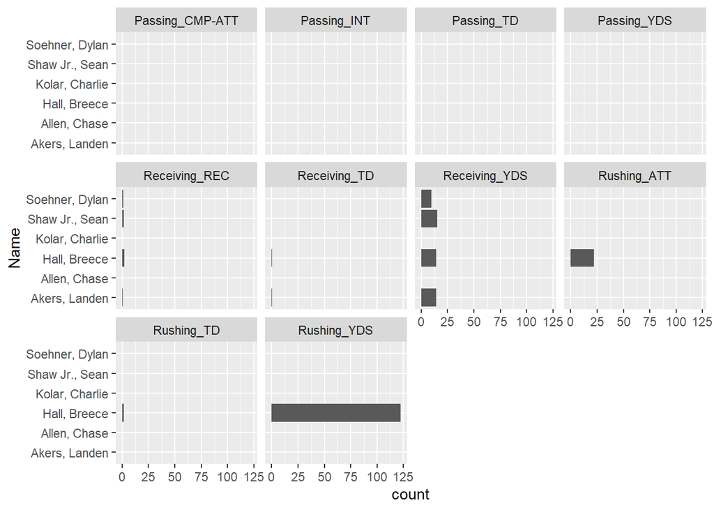

```r
cmp_off <- off2020avg
cmp_off$avg_val = off2020avg$avg_val - off2019avg$avg_val
cmp_off %>%
  ggplot(aes(x=Name, weight=avg_val)) + geom_bar() + facet_wrap(~stat) + coord_flip()
```